3. Repeat a. and b. using a log-transform of the rainfall measurement. Which analysis do you prefer and why?

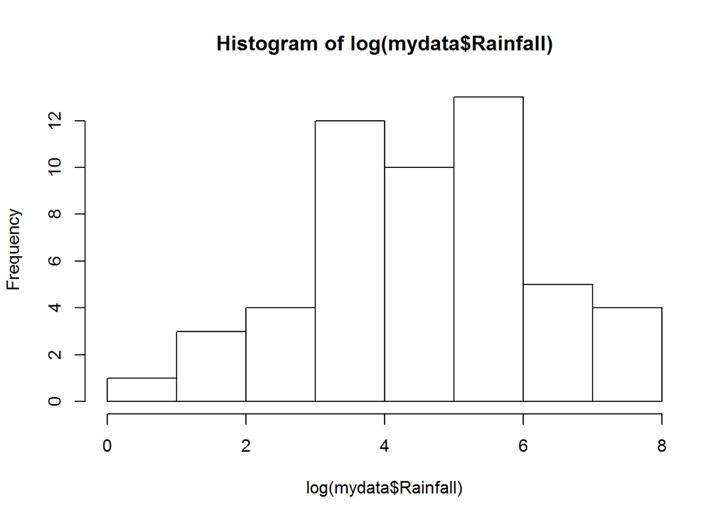

```r
mydata <- case0301
hist(log(mydata$Rainfall))
```

```r
t.test(data=mydata, log(Rainfall) ~ Treatment)
```

```
##
##  Welch Two Sample t-test
##
## data:  log(Rainfall) by Treatment
## t = 2.5444, df = 49.966, p-value = 0.01408
## alternative hypothesis: true difference in means is not equal to 0
## 95 percent confidence interval:
##  0.2408498 2.0467125
## sample estimates:
##   mean in group Seeded mean in group Unseeded
##               5.134187               3.990406
```

Welch Two Sample t-test

data: log(Rainfall) by Treatment t = 2.5444, df = 49.966, p-value = 0.01408 alternative hypothesis: true difference in means is not equal to 0 95 percent confidence interval: 0.2408498 2.0467125 sample estimates: mean in group Seeded mean in group Unseeded 5.134187 3.990406

Running a log-transform does sharpen the t-value and p-value immensely, and heightens the degrees of freedom as well. It also brings the sample estimates closer to one another, which is probably more the case, as it accounts better for errors. I would prefer this log-transformed take.

4. Why is it important that the pilots were unaware of whether they were seeding or not?

Because they would have altered their pattern or speed if they had known if they were seeding clouds, increasing the unaccountable errors in the statistical measures.

5. Unfortunately, we do not have the date of the weather event. Why would it be helpful to have this information?

Because perhaps the biggest error factor here is whether a weather event occurred naturally, or if it happened because of the cloud-seeding. That could have rendered the whole experiment either obsolete or potentially easier to calculate.

2. ANOVA

Here are some simple data describing average daily temperatures for different cities grouped by season.

```r
# Create a dataset
temp = c(60,65,62,64,63,80,85,82,84,83,90,95,101,99,100)
season = rep( c('Fall', 'Spring', 'Summer'), times=c(5,5,5))

data <- data.frame(temp=temp, season=season)
```

For the air temperature data, conduct an ANOVA and use the F-statistic to test the hypothesis that air temperature varies by season.

```r
aov(temp~season, data=data)
```

```
## Call:
##    aov(formula = temp ~ season, data = data)
##
## Terms:
##                   season Residuals
## Sum of Squares  2952.133   111.600
## Deg. of Freedom        2        12
##
## Residual standard error: 3.04959
## Estimated effects may be unbalanced
```

Call: aov(formula = temp ~ season, data = data)

Terms: season Residuals Sum of Squares 2952.133 111.600 Deg. of Freedom 2 12

Residual standard error: 3.04959 Estimated effects may be unbalanced

The residual standard error of 3 suggests that the data does show some linearity, so I could say with some confidence that yes, the temperature does vary by season.

3. Spock Conspiracy Trial.

This is another classic dataset. Dr. Benjamin Spock was a pediatrician who wrote a very popular book in 1948. In 1968, Dr Spock was accused of conspiring to violate the Selective Services Act by helping young men to medically avoid the military draft during the Vietnam War. His defence challenged the case on the grounds that the jury did not contain a single woman, and therefore could not be random.

These data used here contain jury compositions for Spock’s judge and 6 other judges in the same court. For each jury, we have the fraction of the jury that was female.

```r
data(case0502)
```

1. Qualitatively describe these data using boxplots and summary statistics.

Percent Judge  
Min. : 6.40 A :5  
1st Qu.:19.95 B :6  
Median :27.50 C :9  
Mean :26.58 D :2  
3rd Qu.:32.38 E :6  
Max. :48.90 F :9  
Spock’s:9

This was the summary, above. The mean suggests that, overall, about 26.6 percent of all jurors in the court were female. The boxplots, however, demonstrate that something was fishy:

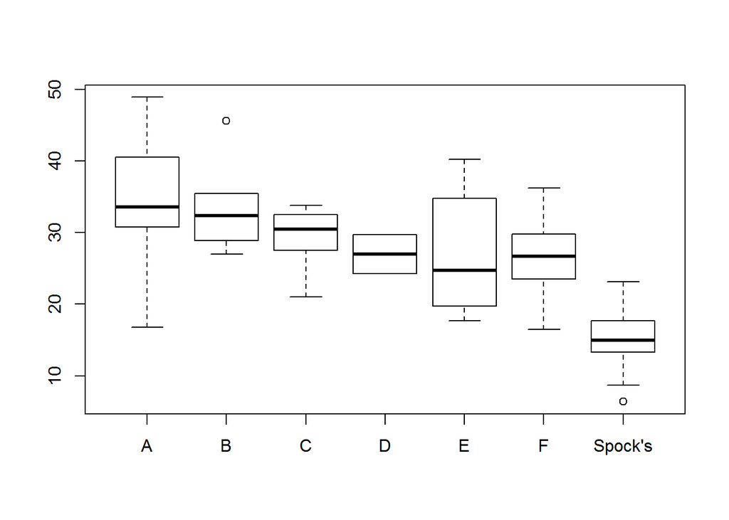

```r
spock <- case0502
boxplot(Percent~Judge, data=spock)
```

This makes visible how relatively few jurors Spock had in his case were female, compared to judges A through F. Treachery afoot?

2. Using an ANOVA, test the hypothesis that all of the judges have the same jury compositions on average and report your results.

Call: aov(formula = Percent ~ Judge, data = spock)

Terms: Judge Residuals Sum of Squares 1927.081 1864.445 Deg. of Freedom 6 39

Residual standard error: 6.914209 Estimated effects may be unbalanced

Welch Two Sample t-test

data: Percent by Judge t = 7.1597, df = 17.608, p-value = 1.303e-06 alternative hypothesis: true difference in means is not equal to 0 95 percent confidence interval: 10.49935 19.23999 sample estimates: mean in group Others mean in group Spocks 29.49189 14.62222

4. Use another ANOVA to evaluate whether or not it was suitable to group together the other 6 judges.

Call: aov(formula = Percent ~ Judge, data = spock3)

Terms: Judge Residuals Sum of Squares 1600.623 2190.903 Deg. of Freedom 1 44

Residual standard error: 7.056433 Estimated effects may be unbalanced

5. How should your interpretation of the results in part (c) change if you rejected the hypothesis the other six judges were not all statistically the same?

The t-value already suggests that we must reject the null hypothesis, so we would need to perhaps run a log-transfer of the data to see if we could standardize it to the point where we could run all six judges against one another with fewer variables.